[figure not shown]

# Universidad de Buenos Aires

## Laboratorio de Sistemas Embebidos

### Especialización en Inteligencia Artificial

#### Probabilidad y Estadística para la Inteligencia Artificial

**Docente**: Camilo Argoty

**Alumno**: Gaspar Acevedo Zain

**Código**: a2101

**Fecha**: 25/05/2025

## Ejercicio número 1

### Enunciado

(3 puntos) De 10 monedas hay 7 monedas falsas, que tienen probabilidad 0,2 de mostrar cara al ser lanzadas.

Si se toma una moneda al azar, se lanza 14 veces, y en todas ellas se obtiene cara, ¿qué es más probable, que la moneda elegida sea justa o que esté cargada?

Dar las probabilidades tanto de que la moneda elegida sea falsa, como de que sea justa.

### Paso 1 - Definir Eventos y sus probabilidades

Definamos los siguientes eventos:

- $C_1$: Sale Cara. Es el complemento a Sale Cruz ($C_2$).
- $C_2$: Sale Cruz. Es el complemento a Sale Cara ($C_1$).
- $M_f$: Moneda Falsa. Complemento de Moneda Justa ($M_j$).
- $M_j$: Moneda Justa. Complemento de Moneda Falsa ($M_f$).

Además, tenemos estos eventos condicionales, según el enunciado:

- $C_1/M_f$: corresponde al evento en el que sale una *Cara* ($C_1$), sabiendo que la moneda es *Falsa* ($M_f$)
- $C_1/M_j$: corresponde al evento en el que sale una *Cara* ($C_1$), sabiendo que la moneda es *Justa* ($M_j$)
- $C_2/M_f$: corresponde al evento en el que sale una *Cruz* ($C_2$), sabiendo que la moneda es *Falsa* ($M_f$)
- $C_2/M_j$: corresponde al evento en el que sale una *Cruz* ($C_2$), sabiendo que la moneda es *Justa* ($M_j$)

A partir del enunciado definimos las siguientes probabilidades:

Por último, definimos las siguientes probabilidades condicionales

- $P(C_1/M_j) = P(C_2/M_j) = 0,5$
  - Asumimos que $C_1/M_j$ y $C_2/M_j$ son equiprobables, ya que la moneda es justa
    - De aquí se tiene que $P(C_1/M_j) = P(C_2/M_j)$
  - Dado a que $C_1/M_j$ y $C_2/M_j$ son complementarios, $P(C_1/M_j) + P(C_2/M_j) = 1$
  - Como $P(C_1/M_j) = P(C_2/M_j)$, tenemos
    - $2*P(C_1/M_j) = 1$
    - $P(C_1/M_j)= 1/2 = 0,5$

### Paso 2 - Planteamos el problema

El enunciado indica que

1. Se toma una moneda al azar.
2. Esa misma moneda, se lanza 14 veces, y en cada tirada se obtiene cara.

De aquí podemos asumir y deducir lo siguiente:

1. Las 14 tiradas (o experimentos) son independientes, y en cada una de ellas siempre se usa la misma moneda.
2. Sabemos que el resultado de cada experimento siempre fue Cara
3. Dado lo anterior, nos interesa saber si, sabiendo que el resultado fue Cara, la moneda está cargada o es justa
4. Es decir, se nos pregunta la probabilidad de los eventos
   1. $M_j/C_1$ o *Moneda Justa*, sabiendo que salió *Cara*
   2. $M_f/C_1$ o *Moneda Falsa*, sabiendo que salió *Cara*
5. Como $M_f/C_1$ y $M_j/C_1$, sus probabilidades suman 1
   1. $P(M_f/C_1) + P(M_j/C_1) = 1$

> Para calcular $P(M_f/C_1)$ nos valemos del teorema de Bayes:

$P(M_f/C_1) = \frac{P(C_1 \cap M_f)}{P(C_1)}$

> Análogamente:

$P(M_j/C_1) = \frac{P(C_1 \cap M_j)}{P(C_1)}$

### Paso 3 - Resolvemos la probabilidad condicional $P(M_f/C_1)$ y $P(M_j/C_1)$

> Gracias al Teorema de Bayes sabemos que:

$P(M_f/C_1) = \frac{P(C_1 \cap M_f)}{P(C_1)}$

> $P(C_1)$ se puede expresar de la siguiente manera:

$P(C_1) = P(C_1 \cap M_f) + P(C_1 \cap M_j)$

> Nuevamente, gracias al Teorema de Bayes podemos expresar lo siguiente:

$P(C_1 \cap M_f) = P(M_f) * P(\frac{C_1}{M_f})$

$P(C_1 \cap M_j) = P(M_j) * P(\frac{C_1}{M_j})$

> Es decir, podemos expresar $P(C_1 \cap M_f)$ y $P(C_1)$ mediante probabilidades que obtuvimos en el Paso 2.

$P(C_1) = P(M_f) * P(\frac{C_1}{M_f}) + P(M_j) * P(\frac{C_1}{M_j})$

$P(C_1) = 0,7 * 0,2 + 0,3 * 0,5$

$P(C_1) = 0,29$

> Obtuvimos que $P(C_1) = 0,29$

> Además, obtuvimos que $P(C_1 \cap M_f) = 0,14$ y $P(C_1 \cap M_j) = 0,15$

> Calculamos las probabilidades condicionales $P(M_f/C_1)$ y $P(M_j/C_1)$

$P(M_f/C_1) = \frac{P(C_1 \cap M_f)}{P(C_1)} = \frac{0,14}{0,29} = 0,48275862 \approx 0,4827$

$P(M_j/C_1) = \frac{P(C_1 \cap M_j)}{P(C_1)} = \frac{0,15}{0,29} = 0,517241379 \approx 0,5173$

> Obtuvimos que $P(M_f/C_1) \approx 0,4827$ y que $P(M_j/C_1) \approx 0,5173$

### Paso 4 - Calculamos las probabilidades para 14 eventos

> En el paso anterior obtuvimos que $P(M_f/C_1) \approx 0,4827$ y que $P(M_j/C_1) \approx 0,5173$

> Ahora, queremos saber cuales son las probabilidades de repetir cada evento 14 veces. Para ello, nos valemos de la fórmula de *Variable Aleatoria Binomial*, ya que lo que nosotros buscamos es la probabilidad de que, al repetir 14 eventos independientes, obtengamos 14 éxitos.

$P(k-éxitos) = C_{n,k} * p^{k} * (1-p)^{n-k}$

- $n$: Cantidad de experimentos independientes, siendo en nuestro caso $14$
- $k$: Cantidad de éxitos, siendo en nuestro caso $14$
- $C_{n,k}$: Combinatorias de $n$, tomadas de a $k$

> A partir de lo anterior, definimos la combinatoria $C_{n,k}$ de esta manera:

> Definimos lo siguiente:

$C_{n,k} = \frac{n!}{(n-k)! * k!)} = \frac{14!}{(14-14)! * 14!} = \frac{14!}{1 * 14!} = 1$

> Reemplazando en la fórmula de *Variable Aleatoria Binomial*:

$P(k-éxitos=14) = C_{n,k} * p^{k} * (1-p)^{n-k} = 1 * p^{14} * (1-p)^{14-14} = p^{14} * (1-p)^{0} = p^{14} * 1 = p^{14}$

> Es decir, para el caso de repetir 14 experimentos y obtener 14 éxitos, la probabilidad está dada por $P(k-éxitos=14) = p^{14}$

> Considerando que nuestro caso de éxito sea que la moneda sea falsa, sabiendo que salió Cara, es decir $M_f/C_1$

$p = P(M_f/C_1) \approx 0,4827$

$P(k-éxitos=14) = p^{14} \approx 0,4827^{14} \approx 0,00003734$

> Considerando que nuestro caso de éxito sea que la moneda sea Justa, sabiendo que salió Cara, es decir $M_j/C_1$

$p = P(M_j/C_1) \approx 0,5173$

$P(k-éxitos=14) = p^{14} \approx 0,5173^{14} \approx 0,000098108$

### Paso 5 - Respuesta

Sabiendo que:

- De 10 monedas hay 7 monedas falsas
- La monedas falsas tienen probabilidad 0,2 de mostrar cara al ser lanzadas
- Se tomó una moneda al Azar y se lanzó 14 veces, y en todas ellas se obtuvo cara

> Respuesta: Podemos decir que es más probable que la moneda sea **Justa**
- La probabilidad que la moneda sea Justa, sabiendo que salió Cara es $\approx 0,5173$
  - $P(M_j/C_1) \approx 0,5173$
  - Si repetimos el evento anterior (que la moneda sea Justa, sabiendo que salió Cara) 14 veces, obtenemos una probabilidad de $\approx 0,000098108$
    - $P(k-éxitos=14) = p^{14} \approx 0,5173^{14} \approx 0,000098108$
- La probabilidad que la moneda sea Falsa, sabiendo que salió Cara es $\approx 0,4827$
  - $P(M_f/C_1) \approx 0,4827$
  - Si repetimos el evento anterior (que la moneda sea Falsa, sabiendo que salió Cara) 14 veces, obtenemos una probabilidad de $\approx 0,00003734$
    - $P(k-éxitos=14) = p^{14} \approx 0,4827^{14} \approx 0,00003734$

## Ejercicio número 2

### Enunciado

(3 puntos) Sean X e Y dos v.a. continuas con densidad conjunta:

$ f_{X,Y} = \begin{cases} Ky & \text{si } 9x^{2} \le y \le 5x \\ 0 & \text{en otro caso} \end{cases} $

Encontrar:

a. Determine el Valor de K b. Encuentre la densidad marginal $f_Y(y)$ de $Y$ c. Encuentre la densidad condicional $f_{X|Y}(x|y)$ de $X$ dado $Y$

### Paso 1 - Definimos el rango de X en la función de densidad conjunta

Según el enunciado, tenemos una función de densidad conjunta definida de la siguiente manera:

$ f_{X,Y} = \begin{cases} Ky & \text{si } 9x^{2} \le y \le 5x \\ 0 & \text{en otro caso} \end{cases} $

De la misma podemos saber que la variable $Y$ está definida por el rango $9x^{2} \le y \le 5x$, pero no tenemos un rango definido para la variable $X$.

Para hallarlo, primero graficamos ambas funciones, enfocándonos en el área definida por ambas.

> Se realiza gráfico de ambas funciones mediante matplotlib

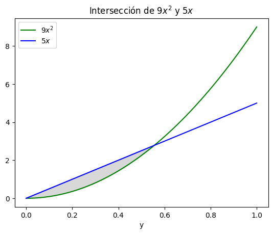

```python
import matplotlib.pyplot as plt
import numpy as np

x = np.linspace(0, 1)
y1 = 9*x**2
y2 = 5*x

# Create the plot
fig, ax = plt.subplots()

ax.plot(x, y1, label='$9x^2$', color="green")
ax.plot(x, y2, label='$5x$', color="blue")

# Fill the area between the functions
ax.fill_between(x, y1, y2, where=y1 <= y2, color='gray', alpha=0.3)

ax.set_xlabel('x')
ax.set_xlabel('y')
ax.set_title('Intersección de $9x^2$ y $5x$')
ax.legend()
plt.show()
```

Del gráfico anterior podemos deducir que nuestro área de interés es aquel definido por el área **coloreado en gris**, delimitado por $9x^{2}$ y $5x$.

El intervalo de la variable $Y$ es aquel que define el enunciado:

- $9x^{2} \le y \le 5x$

Mientras que al intervalo de $X$ lo podemos calcular al hacer la intersección de las funciones $9x^{2}$ y $5x$:

$9x^{2} = 5x$

$9x^{2} - 5x = 0$

$x(9x - 5) = 0$

De lo que obtenemos lo siguiente:

- $x_1 = 0$
- $x_2 = \frac{5}{9}$

Entonces, la función de Densidad conjunta está definida de esta manera:

$ f_{X,Y} = \begin{cases} Ky & \text{si } 9x^{2} \le y \le 5x &;& 0 \le x \le \frac{5}{9} \\ 0 & \text{en otro caso} \end{cases} $

### Paso 2 - Determinamos el valor de K

Por definición, sabemos que la doble integral de la función de Densidad Conjunta entre los intervalos $X$ e $Y$ es igual a $1$, es decir:

$1 = \int_{0}^{\frac{5}{9}}\int_{9x^2}^{5x}Ky\,dy\,dx$

> Comenzamos integrando respecto a Y

$1 = K*\int_{0}^{\frac{5}{9}}\int_{9x^2}^{5x}y\,dy\,dx$

$1 = K*\int_{0}^{\frac{5}{9}}(\frac{y^{2}}{2})|_{9x^2}^{5x}\,dx$

$1 = K*\int_{0}^{\frac{5}{9}}(\frac{(5x)^{2}}{2} - \frac{(9x^2)^2}{2})\,dx$

$1 = K*\int_{0}^{\frac{5}{9}}(\frac{25x^2}{2} - \frac{81x^4}{2})\,dx$

$1 = K * (\frac{25x^3}{6} - \frac{81x^5}{10})|_{0}^{\frac{5}{9}}$

$1 = \frac{625}{2187} * K$

$ K = \frac{2187}{625}$

> Por lo tanto, la Función de Densidad Conjunta de las variables aleatorias continuas X e Y queda definida como:

$ f_{X,Y} = \begin{cases} \frac{2187}{625}y & \text{si } 9x^{2} \le y \le 5x &;& 0 \le x \le \frac{5}{9} \\ 0 & \text{en otro caso} \end{cases} $

### Paso 3 - Definimos la Densidad Marginal $f_Y(y)$ de $Y$

La Densidad Marginal $f_Y(y)$ de $Y$ se define como la integral en función de la variable $X$ de la Función de Densidad Conjunta

$ f_{X,Y} = \begin{cases} \frac{2187}{625}y & \text{si } 9x^{2} \le y \le 5x &;& 0 \le x \le \frac{5}{9} \\ 0 & \text{en otro caso} \end{cases} $

Eso significa que tomamos a $Y$ como $Variable Libre$, y a $X$ como $Variable Condicionada$.

Para ello, debemos expresar el rango de $Y$ entre dos números, y al de $X$ en funcion de $Y$.

Comenzamos definiendo al rango de $X$ en función de $Y$ Expresamos a las funciones $y=9x^2$ e $y=5x$ en función de $x$, quedando

- Límite inferior del rango de $X$
  - $y=9x^2$
  - $(\frac{y}{9})^{1/2} = x$
  - $x = \frac{y^{1/2}}{3}$
- Límite superior del rango de $X$
  - $y=5x$
  - $x = \frac{y}{5}$

El rango de $Y$ se calcula como la intersección de $x = \frac{y}{5}$ y $x = \frac{y^{1/2}}{3}$

$\frac{y}{5} = \frac{y^{1/2}}{3}$

Elevamos al cuadrado ambos términos para facilitar su resolución

$\frac{y^2}{25} = \frac{y}{9}$

$\frac{y^2}{25} - \frac{y}{9} = 0$

$y*(\frac{y}{25} - \frac{1}{9}) = 0$

De lo que obtenemos lo siguiente:

- $y_1 = 0$
- $y_2 = \frac{25}{9}$

Procedemos a calcular la Densidad marginal de $f_Y(y)$:

$f_Y(y) = \int_{\frac{y}{5}}^{\frac{y^{1/2}}{3}}\frac{2187}{625}y\,dx$

$f_Y(y) = \frac{2187}{625} * \int_{\frac{y}{5}}^{\frac{y^{1/2}}{3}}y\,dx$

$f_Y(y) = \frac{2187}{625} * y * (x)|_{\frac{y}{5}}^{\frac{y^{1/2}}{3}}\,dx$

$f_Y(y) = \frac{2187}{625} * y * (\frac{y^{1/2}}{3} - \frac{y}{5})$

$f_Y(y) = \frac{2187}{625} * (\frac{y^{3/2}}{3} - \frac{y^2}{5})$

Entonces, la función Densidad marginal de $f_Y(y)$ queda definida como:

$ f_Y(y) = \begin{cases} \frac{2187}{625} * (\frac{y^{3/2}}{3} - \frac{y^2}{5}) & \text{si } 0 \le y \le \frac{25}{9} \\ 0 & \text{en otro caso} \end{cases} $

### Paso 4 - Definimos la función Densidad condicional $f_{X|Y}(x|y)$ de $X$ dado $Y$

Por definición, la función Densidad condicional $f_{X|Y}(x|y)$ de $X$ dado $Y$ es:

$f_{X|Y}(x|y) = \frac{f_{X,Y}(x,y)}{f_Y(y)}$

Siendo $f_{X,Y}(x,y)$ la Función Densidad Conjunta (ver Paso 2 de este ejercicio):

$ f_{X,Y} = \begin{cases} \frac{2187}{625}y & \text{si } 9x^{2} \le y \le 5x &;& 0 \le x \le \frac{5}{9} \\ 0 & \text{en otro caso} \end{cases} $

Y siendo $f_Y(y)$ la Función Densidad Marginal (ver Paso 3 de este ejercicio):

$ f_Y(y) = \begin{cases} \frac{2187}{625} * (\frac{y^{3/2}}{3} - \frac{y^2}{5}) & \text{si } 0 \le y \le \frac{25}{9} \\ 0 & \text{en otro caso} \end{cases} $

Calculamos la función Densidad condicional $f_{X|Y}(x|y)$ de $X$ dado $Y$:

$f_{X|Y}(x|y) = \frac{f_{X,Y}(x,y)}{f_Y(y)}$

$f_{X|Y}(x|y) = \frac{2187}{625}y * \frac{1}{\frac{2187}{625} * (\frac{y^{3/2}}{3} - \frac{y^2}{5})}$

$f_{X|Y}(x|y) = y * \frac{1}{\frac{y^{3/2}}{3} - \frac{y^2}{5}}$

$f_{X|Y}(x|y) = y * \frac{1}{\frac{5y^{3/2}-3y^{2}}{15}}$

$f_{X|Y}(x|y) = \frac{15y}{5y^{3/2}-3y^{2}}$

Finalmente, tenemos:

$ f_{X|Y}(x|y) = \begin{cases} \frac{15y}{5y^{3/2}-3y^{2}} & \text{si } \frac{y}{5} \le x \le \frac{y^\frac{1}{2}}{3} &;& \text{para } 0 \lt y \lt \frac{25}{9} \text{ fijo}\\ 0 & \text{en otro caso} \end{cases} $

### Paso 5 - Respuestas

> a) Determine el valor de $K$ (ver Paso 2):

$K = \frac{2187}{625}$

> b) Encontrar la densidad marginal $f_Y(y)$ de $Y$ (ver Paso 3):

$ f_Y(y) = \begin{cases} \frac{2187}{625} * (\frac{y^{3/2}}{3} - \frac{y^2}{5}) & \text{si } 0 \le y \le \frac{25}{9} \\ 0 & \text{en otro caso} \end{cases} $

> c) Encontrar la Densidad condicional $f_{X|Y}(x|y)$ de $X$ dado $Y$ (ver Paso 4):

$ f_{X|Y}(x|y) = \begin{cases} \frac{15y}{5y^{3/2}-3y^{2}} & \text{si } \frac{y}{5} \le x \le \frac{y^\frac{1}{2}}{3} &;& \text{para } 0 \lt y \lt \frac{25}{9} \text{ fijo}\\ 0 & \text{en otro caso} \end{cases} $

## Ejercicio número 3

### Enunciado

(4 puntos) Don Francisco es un pequeño comerciante de barrio que posee un supermercado, con el que sostiene su familia.  
Uno de sus hijos, Matías, quien recién inicia a cursar la Especialización en Inteligencia Artificial del LSE de la UBA, le  
propone hacer un análisis de las ventas durante el año anterior, con el fin de hacer pronósticos para el año siguiente, lo que  
a don Francisco le parece buena idea.  
Don Francisco le entrega a Matías el cuaderno donde tiene registrado el valor total de sus ventas en cada día del año. Con  
esta información, Matías construye una tabla en la cual la primera columna corresponde a la fecha y la segunda corresponde  
al monto de las ventas, en dólares para evitarse dolores de cabeza con la inflación. Matías no se siente muy seguro de la  
tarea a realizar, así que les pide ayuda a ustedes para abordar el problema.  
A partir del archivo de datos correspondiente a su grupo, determine una función empírica de distribución y una aproximación  
a la función de densidad de las ventas del supermercado de Don Francisco para cada año de registro (2021, 2022 y 2023):

### Paso 1 - Import + creación de dataframes

Importamos las librerías necesarias:

- [Pandas](https://pandas.pydata.org/) para manejo de datos
- [Matplotlib.pyplot](https://matplotlib.org/3.5.3/api/_as_gen/matplotlib.pyplot.html) que permite configurar gráficos según necesitemos
- [Seaborn](https://seaborn.pydata.org/), una library basada en `Matplotlib`, que permite realizar gráficos estadísticos, incluyendo la *función empírica de distribución* y *función de densidad* para este ejercicio

Cada fila del dataframe corresponde a una venta diferente, con sus respectivos datos de `Fecha` y `Venta`

```python
import pandas as pd
import matplotlib.pyplot as plt
import seaborn as sns

df_ventas = pd.read_excel('Datos_primer_TP_21Co2025_a2101.xlsx')
ventas_totales = df_ventas.Ventas
```

- `df_2021`: Corresponde a las ventas del año **2021**.
- `df_2022`: Corresponde a las ventas del año **2022**.
- `df_2023`: Corresponde a las ventas del año **2023**.

Luego, usando cada dataframe, obtenemos los datos de las ventas de cada uno:

- `ventas_2021`: creado a partir del dataframe `df_2021`. Contiene los datos de la columna `Ventas` para el año **2021**.
- `ventas_2022`: creado a partir del dataframe `df_2022`. Contiene los datos de la columna `Ventas` para el año **2022**.
- `ventas_2023`: creado a partir del dataframe `df_2023`. Contiene los datos de la columna `Ventas` para el año **2023**.

Todas estas variables nos facilitarán el análisis de las ventas por cada año por separado.

```python
# Dividimos por año
df_ventas["FechaAño"] = df_ventas["Fecha"].dt.year

# Creamos un DataFrame por cada año
df_2021 = df_ventas[df_ventas["FechaAño"] == 2021]
ventas_2021 = df_2021.Ventas
df_2022 = df_ventas[df_ventas["FechaAño"] == 2022]
ventas_2022 = df_2022.Ventas
df_2023 = df_ventas[df_ventas["FechaAño"] == 2023]
ventas_2023 = df_2023.Ventas

# Validamos que la suma de los DF de cada año sea igual al total
len(ventas_totales) == (len(ventas_2021) + len(ventas_2022) + len(ventas_2023))
```

```
True
```

### Paso 2.0 - Respuesta - Gráfico de Función Empírica de Distribución y Función de Densidad de Ventas por año

En el siguiente paso graficamos la funciones `Función Empírica de Distribución` (a la izquierda) y `Función de Densidad de Probabilidad` (a la derecha), de las Ventas **por año**.

- Para graficar la `Función Empírica de Distribución` de las *Ventas por año* utilizamos la función [ecdfplot](https://seaborn.pydata.org/generated/seaborn.ecdfplot.html), o **Empirical Commutative Distribution Function**, de seaborn.
- Para graficar la `Función de Densidad de Probabilidad` de las *Ventas por año* utilizamos la función [kdplot](https://seaborn.pydata.org/generated/seaborn.kdeplot.html), o **Kernel Density Estimate**, de seaborn.

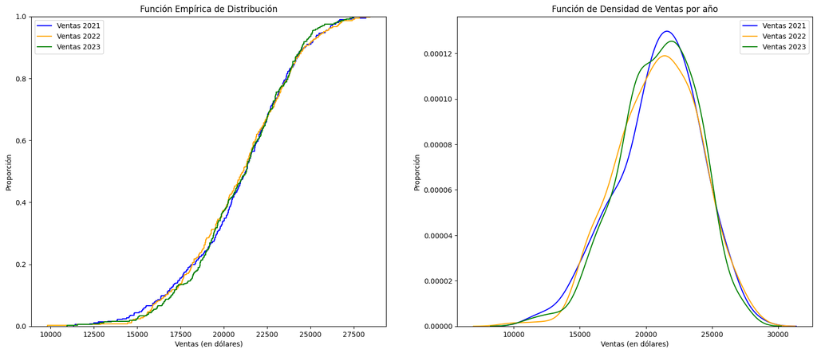

```python
fig, axes = plt.subplots(1, 2, figsize=(20, 8))

axes[0].set_title('Función Empírica de Distribución')
axes[0].set_xlabel("Ventas (en dólares)")
axes[0].set_ylabel("Proporción")
ecdf2021 = sns.ecdfplot(ventas_2021, ax=axes[0], color="blue")
ecdf2022 = sns.ecdfplot(ventas_2022, ax=axes[0], color="orange")
ecdf2023 = sns.ecdfplot(ventas_2023, ax=axes[0], color="green")
axes[0].legend(['Ventas 2021', 'Ventas 2022', 'Ventas 2023'])

axes[1].set_title('Función de Densidad de Ventas por año')
axes[1].set_xlabel("Ventas (en dólares)")
axes[1].set_ylabel("Proporción")
sns2021 = sns.kdeplot(ventas_2021, color="blue")
sns2022 = sns.kdeplot(ventas_2022, color="orange")
sns2023 = sns.kdeplot(ventas_2023, color="green")
axes[1].legend(['Ventas 2021', 'Ventas 2022', 'Ventas 2023'])
```

#### Paso 2.01 - Gráfico de Función Empírica de Distribución y Función de Densidad de Ventas para el año 2021

En el siguiente paso graficamos la funciones `Función Empírica de Distribución` (a la izquierda) y `Función de Densidad de Probabilidad` (a la derecha), de las Ventas **para el año 2021**, para diferenciar mejor a la misma en el gráfico presentado en el `Paso 2.0`:

- Para graficar la `Función Empírica de Distribución` de las *Ventas para el año 2021* utilizamos la función [ecdfplot](https://seaborn.pydata.org/generated/seaborn.ecdfplot.html), o **Empirical Commutative Distribution Function**, de seaborn.
- Para graficar la `Función de Densidad de Probabilidad` de las *Ventas para el año 2021* utilizamos la función [kdplot](https://seaborn.pydata.org/generated/seaborn.kdeplot.html), o **Kernel Density Estimate**, de seaborn.

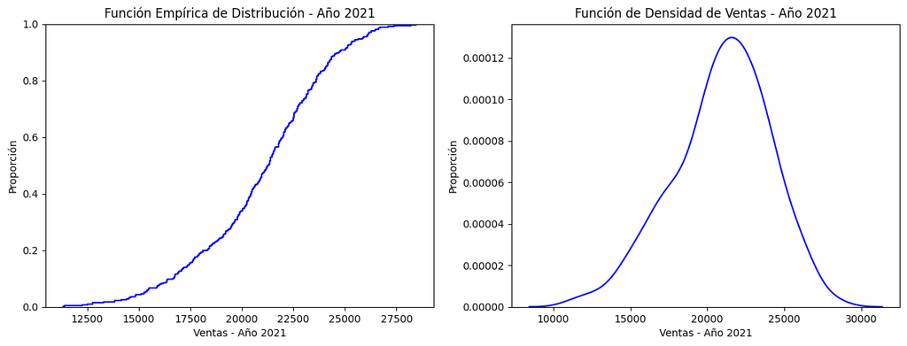

```python
fig, axes = plt.subplots(1, 2, figsize=(15, 5))

# Empirical Commutative Distribution Function
# https://seaborn.pydata.org/generated/seaborn.ecdfplot.html
# https://www.geeksforgeeks.org/how-to-make-ecdf-plot-with-seaborn-in-python/
axes[0].set_title('Función Empírica de Distribución - Año 2021')
axes[0].set_xlabel("Ventas - Año 2021")
axes[0].set_ylabel("Proporción")
sns.ecdfplot(ventas_2021, ax=axes[0], color="blue")

# https://seaborn.pydata.org/generated/seaborn.kdeplot.html
# https://www.geeksforgeeks.org/seaborn-kdeplot-a-comprehensive-guide/
# Función Densidad Probabilidad
axes[1].set_title('Función de Densidad de Ventas - Año 2021')
axes[1].set_xlabel("Ventas - Año 2021")
axes[1].set_ylabel("Proporción")
sns.kdeplot(ventas_2021, ax=axes[1], color="blue")
```

#### Paso 2.02 - Gráfico de Función Empírica de Distribución y Función de Densidad de Ventas para el año 2022

En el siguiente paso graficamos la funciones `Función Empírica de Distribución` (a la izquierda) y `Función de Densidad de Probabilidad` (a la derecha), de las Ventas **para el año 2022**, para diferenciar mejor a la misma en el gráfico presentado en el `Paso 2.0`:

- Para graficar la `Función Empírica de Distribución` de las *Ventas para el año 2022* utilizamos la función [ecdfplot](https://seaborn.pydata.org/generated/seaborn.ecdfplot.html), o **Empirical Commutative Distribution Function**, de seaborn.
- Para graficar la `Función de Densidad de Probabilidad` de las *Ventas para el año 2022* utilizamos la función [kdplot](https://seaborn.pydata.org/generated/seaborn.kdeplot.html), o **Kernel Density Estimate**, de seaborn.

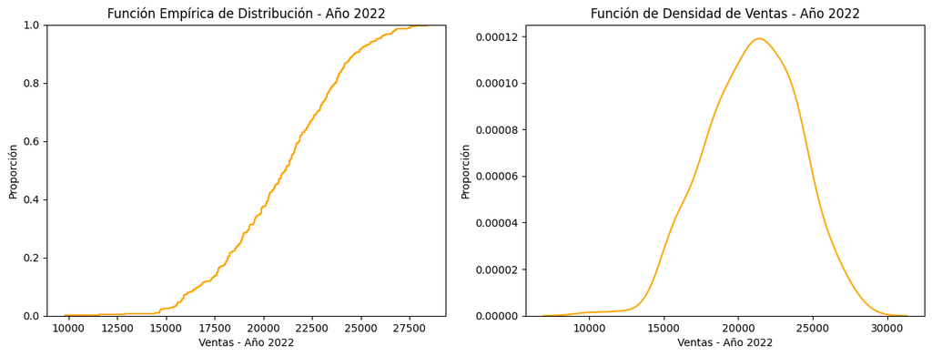

```python
fig, axes = plt.subplots(1, 2, figsize=(15, 5))

# Empirical Commutative Distribution Function
# https://seaborn.pydata.org/generated/seaborn.ecdfplot.html
# https://www.geeksforgeeks.org/how-to-make-ecdf-plot-with-seaborn-in-python/
axes[0].set_title('Función Empírica de Distribución - Año 2022')
axes[0].set_xlabel("Ventas - Año 2022")
axes[0].set_ylabel("Proporción")
sns.ecdfplot(ventas_2022, ax=axes[0], color="orange")

# https://seaborn.pydata.org/generated/seaborn.kdeplot.html
# https://www.geeksforgeeks.org/seaborn-kdeplot-a-comprehensive-guide/
# Función Densidad Probabilidad
axes[1].set_title('Función de Densidad de Ventas - Año 2022')
axes[1].set_xlabel("Ventas - Año 2022")
axes[1].set_ylabel("Proporción")
sns.kdeplot(ventas_2022, ax=axes[1], color="orange")
```

#### Paso 2.03 - Gráfico de Función Empírica de Distribución y Función de Densidad de Ventas para el año 2023

En el siguiente paso graficamos la funciones `Función Empírica de Distribución` (a la izquierda) y `Función de Densidad de Probabilidad` (a la derecha), de las Ventas **para el año 2023**, para diferenciar mejor a la misma en el gráfico presentado en el `Paso 2.0`:

- Para graficar la `Función Empírica de Distribución` de las *Ventas para el año 2023* utilizamos la función [ecdfplot](https://seaborn.pydata.org/generated/seaborn.ecdfplot.html), o **Empirical Commutative Distribution Function**, de seaborn.
- Para graficar la `Función de Densidad de Probabilidad` de las *Ventas para el año 2023* utilizamos la función [kdplot](https://seaborn.pydata.org/generated/seaborn.kdeplot.html), o **Kernel Density Estimate**, de seaborn.

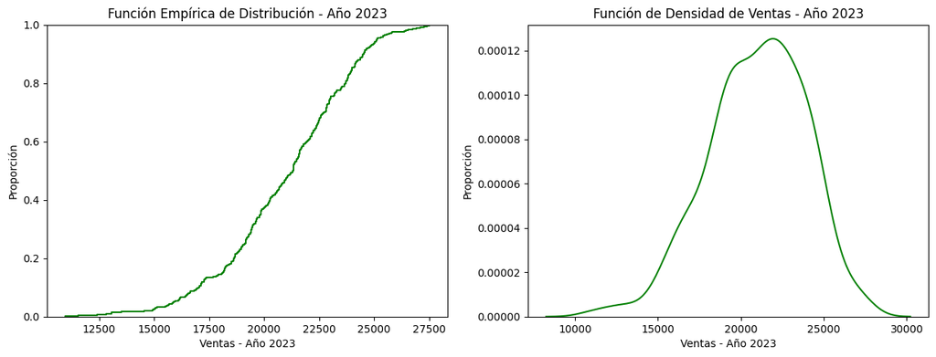

```python
fig, axes = plt.subplots(1, 2, figsize=(15, 5))

# Empirical Commutative Distribution Function
# https://seaborn.pydata.org/generated/seaborn.ecdfplot.html
# https://www.geeksforgeeks.org/how-to-make-ecdf-plot-with-seaborn-in-python/
axes[0].set_title('Función Empírica de Distribución - Año 2023')
axes[0].set_xlabel("Ventas - Año 2023")
axes[0].set_ylabel("Proporción")
sns.ecdfplot(ventas_2023, ax=axes[0], color="green")

# https://seaborn.pydata.org/generated/seaborn.kdeplot.html
# https://www.geeksforgeeks.org/seaborn-kdeplot-a-comprehensive-guide/
# Función Densidad Probabilidad
axes[1].set_title('Función de Densidad de Ventas - Año 2023')
axes[1].set_xlabel("Ventas - Año 2023")
axes[1].set_ylabel("Proporción")
sns.kdeplot(ventas_2023, ax=axes[1], color="green")
```